Skip to contents

# Recipes: the CDISC-pilot tables, end to end

Source: [`vignettes/articles/recipes.qmd`](https://github.com/vthanik/tabular/blob/v0.3.2/vignettes/articles/recipes.qmd)

These are the canonical safety and efficacy tables a programmer builds from the shell — each one rendered **live** below from the bundled demo data, so what you see is exactly what the code produces. They mirror the package’s cross-backend qualification (`inst/qualification/`), which rebuilds the same displays from the real PHUSE Test Data Factory ADaM and checks them across every backend.

Each recipe ends on the spec (the live HTML you see); the closing line shows how to **ship the same spec** to a submission backend — just change the extension.

## Demographics and baseline characteristics

The reference safety table: a grouped parameter stub, indented statistic rows, decimal-aligned arm columns, and the population BigN folded into each header from `cdisc_saf_n`.

```r
n <- stats::setNames(cdisc_saf_n$n, cdisc_saf_n$arm_short)

demo_tbl <- tabular(
  cdisc_saf_demo,
  titles = c(
    "Table 14.1.1",
    "Demographic and Baseline Characteristics",
    "Safety Population"
  ),
  footnotes = "Percentages are based on the number of subjects per treatment group."
) |>
  cols(
    variable = col_spec(label = "Parameter"),
    stat_label = col_spec(label = "Statistic"),
    placebo = col_spec(
      label = "Placebo\nN={n['placebo']}",
      align = "decimal"
    ),
    drug_50 = col_spec(
      label = "Drug 50\nN={n['drug_50']}",
      align = "decimal"
    ),
    drug_100 = col_spec(
      label = "Drug 100\nN={n['drug_100']}",
      align = "decimal"
    ),
    Total = col_spec(label = "Total\nN={n['Total']}", align = "decimal")
  ) |>
  group_rows(by = "variable")

demo_tbl
```

Table 14.1.1

Demographic and Baseline Characteristics

Safety Population

| Statistic | Placebo N=86 | Drug 50 N=96 | Drug 100 N=72 | Total N=254 |
| --- | --- | --- | --- | --- |
| **Age (years)** |  |  |  |  |
| n | 86 | 96 | 72 | 254 |
| Mean (SD) | 75.2 (8.59) | 76.0 (8.11) | 73.8 (7.94) | 75.1 (8.25) |
| Median | 76.0 | 78.0 | 75.5 | 77.0 |
| Q1, Q3 | 69.2, 81.8 | 71.0, 82.0 | 70.5, 79.0 | 70.0, 81.0 |
| Min, Max | 52 , 89 | 51 , 88 | 56 , 88 | 51 , 89 |
| **Sex, n (%)** |  |  |  |  |
| F | 53 (61.6) | 55 (57.3) | 35 (48.6) | 143 (56.3) |
| M | 33 (38.4) | 41 (42.7) | 37 (51.4) | 111 (43.7) |
| **Race, n (%)** |  |  |  |  |
| WHITE | 78 (90.7) | 90 (93.8) | 62 (86.1) | 230 (90.6) |
| BLACK OR AFRICAN AMERICAN | 8 ( 9.3) | 6 ( 6.2) | 9 (12.5) | 23 ( 9.1) |
| ASIAN | 0 | 0 | 0 | 0 |
| AMERICAN INDIAN OR ALASKA NATIVE | 0 | 0 | 1 ( 1.4) | 1 ( 0.4) |

Percentages are based on the number of subjects per treatment group.

```r
emit(demo_tbl, "t_14_1_1.rtf") # ship: or .pdf / .docx / .html / .md
```

## Adverse-event overview

A flat overview: `stat_label` is a plain display column carrying both the high-level flag rows and the two-space-indented maximum-severity detail rows (the indent is baked into the label strings), so each category sits on one line with its counts.

```r
ae_tbl <- tabular(
  cdisc_saf_ae,
  titles = c(
    "Table 14.3.0",
    "Overview of Treatment-Emergent Adverse Events",
    "Safety Population"
  )
) |>
  cols(
    stat_label = col_spec(label = ""),
    placebo = col_spec(
      label = "Placebo\nN={n['placebo']}",
      align = "decimal"
    ),
    drug_50 = col_spec(
      label = "Drug 50\nN={n['drug_50']}",
      align = "decimal"
    ),
    drug_100 = col_spec(
      label = "Drug 100\nN={n['drug_100']}",
      align = "decimal"
    ),
    Total = col_spec(label = "Total\nN={n['Total']}", align = "decimal")
  )

ae_tbl
```

Table 14.3.0

Overview of Treatment-Emergent Adverse Events

Safety Population

|  | Placebo N=86 | Drug 50 N=96 | Drug 100 N=72 | Total N=254 |
| --- | --- | --- | --- | --- |
| Any TEAE | 65 (75.6) | 84 (87.5) | 68 (94.4) | 217 (85.4) |
| Any Serious AE (SAE) | 0 | 2 ( 2.1) | 1 ( 1.4) | 3 ( 1.2) |
| Any AE Related to Study Drug | 43 (50.0) | 77 (80.2) | 64 (88.9) | 184 (72.4) |
| Any AE Leading to Death | 2 ( 2.3) | 1 ( 1.0) | 0 | 3 ( 1.2) |
| Any AE Recovered / Resolved | 47 (54.7) | 61 (63.5) | 49 (68.1) | 157 (61.8) |
| Maximum severity: Mild | 36 (41.9) | 21 (21.9) | 20 (27.8) | 77 (30.3) |
| Maximum severity: Moderate | 24 (27.9) | 47 (49.0) | 40 (55.6) | 111 (43.7) |
| Maximum severity: Severe | 5 ( 5.8) | 16 (16.7) | 8 (11.1) | 29 (11.4) |

```r
emit(ae_tbl, "t_14_3_0.rtf") # ship: or .pdf / .docx / .html / .md
```

## Adverse events by SOC and preferred term

The two-level hierarchy: `label` holds SOC text on SOC rows and PT text on PT rows, indented by `indent_level`; the hidden `soc` / `row_type` / `n_total` / `soc_n` columns ride along as partition and sort keys. `sort_rows()` clusters PTs under their parent SOC and orders both levels by descending frequency.

```r
aesocpt_tbl <- tabular(
  cdisc_saf_aesocpt,
  titles = c(
    "Table 14.3.1",
    "Adverse Events by System Organ Class and Preferred Term",
    "Safety Population"
  )
) |>
  cols(
    label = col_spec(
      label = "SOC / Preferred Term",
      indent = "indent_level"
    ),
    soc = col_spec(visible = FALSE),
    row_type = col_spec(visible = FALSE),
    n_total = col_spec(visible = FALSE),
    soc_n = col_spec(visible = FALSE),
    placebo = col_spec(
      label = "Placebo\nN={n['placebo']}",
      align = "decimal"
    ),
    drug_50 = col_spec(
      label = "Drug 50\nN={n['drug_50']}",
      align = "decimal"
    ),
    drug_100 = col_spec(
      label = "Drug 100\nN={n['drug_100']}",
      align = "decimal"
    ),
    Total = col_spec(label = "Total\nN={n['Total']}", align = "decimal")
  ) |>
  sort_rows(by = c("soc_n", "n_total"), descending = c(TRUE, TRUE))

aesocpt_tbl
```

Table 14.3.1

Adverse Events by System Organ Class and Preferred Term

Safety Population

| SOC / Preferred Term | Placebo N=86 | Drug 50 N=96 | Drug 100 N=72 | Total N=254 |
| --- | --- | --- | --- | --- |
| TOTAL SUBJECTS WITH AN EVENT | 52 (60.5) | 81 (84.4) | 66 (91.7) | 199 (78.3) |
| SKIN AND SUBCUTANEOUS TISSUE DISORDERS | 19 (22.1) | 36 (37.5) | 35 (48.6) | 90 (35.4) |
| PRURITUS | 8 ( 9.3) | 21 (21.9) | 25 (34.7) | 54 (21.3) |
| ERYTHEMA | 8 ( 9.3) | 14 (14.6) | 14 (19.4) | 36 (14.2) |
| RASH | 5 ( 5.8) | 13 (13.5) | 8 (11.1) | 26 (10.2) |
| HYPERHIDROSIS | 2 ( 2.3) | 4 ( 4.2) | 8 (11.1) | 14 ( 5.5) |
| SKIN IRRITATION | 3 ( 3.5) | 6 ( 6.2) | 5 ( 6.9) | 14 ( 5.5) |
| GENERAL DISORDERS AND ADMINISTRATION SITE CONDITIONS | 15 (17.4) | 36 (37.5) | 30 (41.7) | 81 (31.9) |
| APPLICATION SITE PRURITUS | 6 ( 7.0) | 23 (24.0) | 21 (29.2) | 50 (19.7) |
| APPLICATION SITE ERYTHEMA | 3 ( 3.5) | 13 (13.5) | 14 (19.4) | 30 (11.8) |
| APPLICATION SITE DERMATITIS | 5 ( 5.8) | 9 ( 9.4) | 7 ( 9.7) | 21 ( 8.3) |
| APPLICATION SITE IRRITATION | 3 ( 3.5) | 9 ( 9.4) | 9 (12.5) | 21 ( 8.3) |
| APPLICATION SITE VESICLES | 1 ( 1.2) | 5 ( 5.2) | 5 ( 6.9) | 11 ( 4.3) |
| GASTROINTESTINAL DISORDERS | 13 (15.1) | 12 (12.5) | 17 (23.6) | 42 (16.5) |
| DIARRHOEA | 9 (10.5) | 5 ( 5.2) | 3 ( 4.2) | 17 ( 6.7) |
| VOMITING | 3 ( 3.5) | 4 ( 4.2) | 6 ( 8.3) | 13 ( 5.1) |
| NAUSEA | 3 ( 3.5) | 3 ( 3.1) | 6 ( 8.3) | 12 ( 4.7) |
| ABDOMINAL PAIN | 1 ( 1.2) | 3 ( 3.1) | 1 ( 1.4) | 5 ( 2.0) |
| SALIVARY HYPERSECRETION | 0 | 0 | 4 ( 5.6) | 4 ( 1.6) |
| NERVOUS SYSTEM DISORDERS | 6 ( 7.0) | 18 (18.8) | 17 (23.6) | 41 (16.1) |
| DIZZINESS | 2 ( 2.3) | 9 ( 9.4) | 10 (13.9) | 21 ( 8.3) |
| HEADACHE | 3 ( 3.5) | 3 ( 3.1) | 5 ( 6.9) | 11 ( 4.3) |
| SYNCOPE | 0 | 5 ( 5.2) | 2 ( 2.8) | 7 ( 2.8) |
| SOMNOLENCE | 2 ( 2.3) | 3 ( 3.1) | 1 ( 1.4) | 6 ( 2.4) |
| TRANSIENT ISCHAEMIC ATTACK | 0 | 2 ( 2.1) | 1 ( 1.4) | 3 ( 1.2) |
| CARDIAC DISORDERS | 7 ( 8.1) | 12 (12.5) | 14 (19.4) | 33 (13.0) |
| SINUS BRADYCARDIA | 2 ( 2.3) | 7 ( 7.3) | 8 (11.1) | 17 ( 6.7) |
| MYOCARDIAL INFARCTION | 4 ( 4.7) | 2 ( 2.1) | 4 ( 5.6) | 10 ( 3.9) |
| ATRIAL FIBRILLATION | 1 ( 1.2) | 2 ( 2.1) | 2 ( 2.8) | 5 ( 2.0) |
| SUPRAVENTRICULAR EXTRASYSTOLES | 1 ( 1.2) | 1 ( 1.0) | 1 ( 1.4) | 3 ( 1.2) |
| VENTRICULAR EXTRASYSTOLES | 0 | 2 ( 2.1) | 1 ( 1.4) | 3 ( 1.2) |
| INFECTIONS AND INFESTATIONS | 12 (14.0) | 6 ( 6.2) | 11 (15.3) | 29 (11.4) |
| NASOPHARYNGITIS | 2 ( 2.3) | 4 ( 4.2) | 6 ( 8.3) | 12 ( 4.7) |
| UPPER RESPIRATORY TRACT INFECTION | 6 ( 7.0) | 1 ( 1.0) | 3 ( 4.2) | 10 ( 3.9) |
| INFLUENZA | 1 ( 1.2) | 1 ( 1.0) | 1 ( 1.4) | 3 ( 1.2) |
| URINARY TRACT INFECTION | 2 ( 2.3) | 0 | 1 ( 1.4) | 3 ( 1.2) |
| CYSTITIS | 1 ( 1.2) | 0 | 1 ( 1.4) | 2 ( 0.8) |
| RESPIRATORY, THORACIC AND MEDIASTINAL DISORDERS | 5 ( 5.8) | 8 ( 8.3) | 9 (12.5) | 22 ( 8.7) |
| COUGH | 1 ( 1.2) | 5 ( 5.2) | 5 ( 6.9) | 11 ( 4.3) |
| NASAL CONGESTION | 3 ( 3.5) | 1 ( 1.0) | 3 ( 4.2) | 7 ( 2.8) |
| DYSPNOEA | 1 ( 1.2) | 1 ( 1.0) | 1 ( 1.4) | 3 ( 1.2) |
| EPISTAXIS | 0 | 1 ( 1.0) | 2 ( 2.8) | 3 ( 1.2) |
| PHARYNGOLARYNGEAL PAIN | 0 | 1 ( 1.0) | 1 ( 1.4) | 2 ( 0.8) |
| PSYCHIATRIC DISORDERS | 7 ( 8.1) | 9 ( 9.4) | 3 ( 4.2) | 19 ( 7.5) |
| CONFUSIONAL STATE | 2 ( 2.3) | 3 ( 3.1) | 1 ( 1.4) | 6 ( 2.4) |
| AGITATION | 2 ( 2.3) | 3 ( 3.1) | 0 | 5 ( 2.0) |
| INSOMNIA | 2 ( 2.3) | 0 | 2 ( 2.8) | 4 ( 1.6) |
| ANXIETY | 0 | 3 ( 3.1) | 0 | 3 ( 1.2) |
| DELUSION | 1 ( 1.2) | 0 | 1 ( 1.4) | 2 ( 0.8) |
| MUSCULOSKELETAL AND CONNECTIVE TISSUE DISORDERS | 3 ( 3.5) | 6 ( 6.2) | 5 ( 6.9) | 14 ( 5.5) |
| BACK PAIN | 1 ( 1.2) | 1 ( 1.0) | 3 ( 4.2) | 5 ( 2.0) |
| ARTHRALGIA | 1 ( 1.2) | 2 ( 2.1) | 1 ( 1.4) | 4 ( 1.6) |
| SHOULDER PAIN | 1 ( 1.2) | 2 ( 2.1) | 0 | 3 ( 1.2) |
| MUSCLE SPASMS | 0 | 1 ( 1.0) | 1 ( 1.4) | 2 ( 0.8) |
| ARTHRITIS | 0 | 0 | 1 ( 1.4) | 1 ( 0.4) |
| INVESTIGATIONS | 5 ( 5.8) | 4 ( 4.2) | 3 ( 4.2) | 12 ( 4.7) |
| ELECTROCARDIOGRAM ST SEGMENT DEPRESSION | 4 ( 4.7) | 1 ( 1.0) | 0 | 5 ( 2.0) |
| ELECTROCARDIOGRAM T WAVE INVERSION | 2 ( 2.3) | 1 ( 1.0) | 1 ( 1.4) | 4 ( 1.6) |
| BLOOD GLUCOSE INCREASED | 0 | 1 ( 1.0) | 1 ( 1.4) | 2 ( 0.8) |
| ELECTROCARDIOGRAM T WAVE AMPLITUDE DECREASED | 1 ( 1.2) | 1 ( 1.0) | 0 | 2 ( 0.8) |
| BIOPSY | 0 | 0 | 1 ( 1.4) | 1 ( 0.4) |

This table is long, so a real deliverable paginates it — keeping each SOC and its preferred terms together. Pagination materialises in the paged backends (RTF, PDF, DOCX), so add `paginate()` and emit to one of those:

```r
aesocpt_tbl |>
  paginate(keep_together = "soc", continuation = "(continued)") |>
  emit("t_14_3_1.pdf")
```

## Best overall response and response rates

The efficacy companion: `group_label` synthesises one bold section band per analysis block (best overall response, ORR, CBR, DCR) via the default `"section"` display, with indented response rows beneath. Denominators come from `cdisc_eff_n`.

```r
ne <- stats::setNames(cdisc_eff_n$n, cdisc_eff_n$arm_short)

resp_tbl <- tabular(
  cdisc_eff_resp,
  titles = c(
    "Table 14.2.1",
    "Best Overall Response and Response Rates",
    "Efficacy Evaluable Population"
  )
) |>
  cols(
    stat_label = col_spec(label = "Response"),
    groupid = col_spec(visible = FALSE),
    row_type = col_spec(visible = FALSE),
    placebo = col_spec(
      label = "Placebo\nN={ne['placebo']}",
      align = "decimal"
    ),
    drug_50 = col_spec(
      label = "Drug 50\nN={ne['drug_50']}",
      align = "decimal"
    ),
    drug_100 = col_spec(
      label = "Drug 100\nN={ne['drug_100']}",
      align = "decimal"
    )
  ) |>
  group_rows(by = "group_label")

resp_tbl
```

Table 14.2.1

Best Overall Response and Response Rates

Efficacy Evaluable Population

| Response | Placebo N=86 | Drug 50 N=84 | Drug 100 N=84 |
| --- | --- | --- | --- |
| **Best Overall Response** |  |  |  |
| CR | 1 ( 1.2) | 1 ( 1.2) | 1 ( 1.2) |
| PR | 1 ( 1.2) | 0 | 0 |
| SD | 1 ( 1.2) | 0 | 0 |
| NON-CR/NON-PD | 0 | 0 | 1 ( 1.2) |
| PD | 0 | 0 | 1 ( 1.2) |
| NE | 0 | 1 ( 1.2) | 0 |
| MISSING | 83 (96.5) | 82 (97.6) | 81 (96.4) |
| **Objective Response Rate** |  |  |  |
| ORR (CR + PR) | 2 (2.3) | 1 (1.2) | 1 (1.2) |
| 95% CI (Clopper-Pearson) | ( 0.3, 8.1) | ( 0.0, 6.5) | ( 0.0, 6.5) |
| **Clinical Benefit Rate** |  |  |  |
| CBR (CR + PR + SD) | 3 (3.5) | 1 (1.2) | 1 (1.2) |
| 95% CI (Clopper-Pearson) | ( 0.7, 9.9) | ( 0.0, 6.5) | ( 0.0, 6.5) |
| **Disease Control Rate** |  |  |  |
| DCR (CR + PR + SD + NON-CR/NON-PD) | 3 (3.5) | 1 (1.2) | 2 (2.4) |
| 95% CI (Clopper-Pearson) | ( 0.7, 9.9) | ( 0.0, 6.5) | ( 0.3, 8.3) |

```r
emit(resp_tbl, "t_14_2_1.rtf") # ship: or .pdf / .docx / .html / .md
```

## A figure in the same chrome

Figure 7.1

Mean Diastolic Blood Pressure by Visit

Safety Population

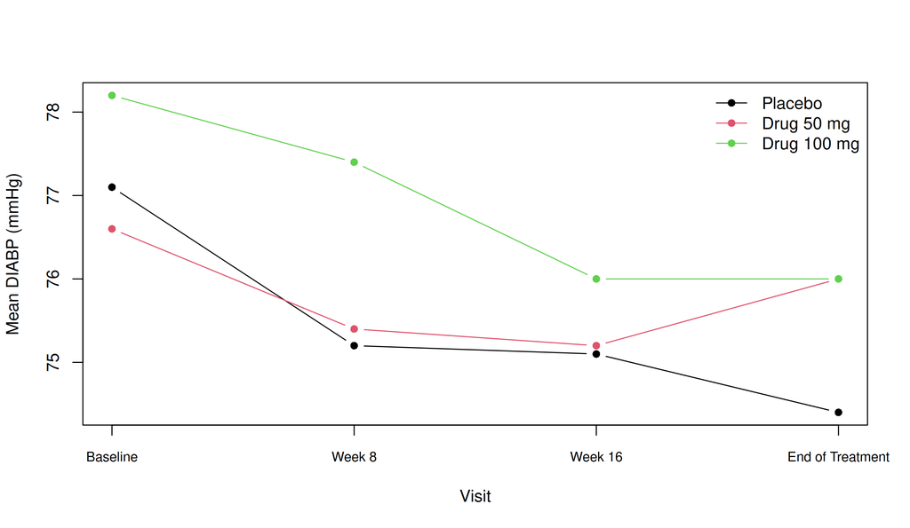

Means are taken from the summary table; error bars omitted for clarity.

```r
# Mean (SD) rows from the bundled vitals summary, read as numeric means.
diabp <- cdisc_saf_vital[
  cdisc_saf_vital$paramcd == "DIABP" &
    cdisc_saf_vital$stat_label == "Mean (SD)",
]
visit_order <- c("Baseline", "Week 8", "Week 16", "End of Treatment")
diabp <- diabp[match(visit_order, diabp$visit), ]
mean_of <- function(x) as.numeric(sub(" .*", "", x))
arms <- c(placebo = "Placebo", drug_50 = "Drug 50 mg", drug_100 = "Drug 100 mg")

draw_diabp <- function() {
  ys <- do.call(cbind, lapply(names(arms), function(a) mean_of(diabp[[a]])))
  matplot(
    seq_along(visit_order),
    ys,
    type = "b",
    pch = 16,
    lty = 1,
    col = seq_along(arms),
    xaxt = "n",
    xlab = "Visit",
    ylab = "Mean DIABP (mmHg)"
  )
  axis(1, at = seq_along(visit_order), labels = visit_order, cex.axis = 0.8)
  legend(
    "topright",
    legend = unname(arms),
    pch = 16,
    lty = 1,
    col = seq_along(arms),
    bty = "n"
  )
}

vital_fig <- figure(
  draw_diabp,
  titles = c(
    "Figure 7.1",
    "Mean Diastolic Blood Pressure by Visit",
    "Safety Population"
  ),
  footnotes = "Means are taken from the summary table; error bars omitted for clarity."
)
vital_fig
```

`emit()` writes a figure to any backend exactly like a table; on the paged backends (RTF, PDF, DOCX) the plot is placed in the body box by `halign` / `valign`, and a list of plots emits one figure per page.

```r
emit(vital_fig, "g_7_1.rtf") # ship: or .pdf / .docx / .html / .md
```

## See also

- Data in — produce these wide frames from a cards/cardx ARD with `pivot_across()`.
- Structure and Presentation — the column, pagination, and styling verbs each recipe draws on.
- Output & qualification — the cross-backend validation these recipes mirror.